# Final Project

David Finder, 113617508

May 9, 2018

###### Final Project

Today we’re going to walk you down the data science pipeline, mostly about how you can find certain historical events in data, but there’s also a fair amount of general exploration of data and how accessible data can be. In particular for this topic, I like talking about demography. Two of my favorite things in life are demography and staring at maps, and I feel like this project combines them quite nicely.

Step one is getting our data sets.

First we’re going to import some nice datasets, like the population by age range per year per country. This data spans from the years 1950 to projected populations in the year 2100.

We’re getting these first two datasets from https://esa.un.org/unpd/wpp/Download/Standard/Population/

All of the other ones are coming from the World Bank data set, https://data.worldbank.org. Search by the metrics listed. I can’t import these directly from the internet because they come with metadata CSVs in addition, and there’s issues with .zip files. The world bank in particular has an amazing data set.

```r
pyramid <- read_csv("WPP2017_PopulationByAgeSex_Medium.csv")
pyramid
```

```
## # A tibble: 725,651 x 12
##    LocID Location    VarID Variant  Time MidPeriod AgeGrp AgeGrpStart
##    <int> <chr>       <int> <chr>   <int>     <dbl> <chr>        <int>
##  1     4 Afghanistan     2 Medium   1950     1950. 0-4              0
##  2     4 Afghanistan     2 Medium   1950     1950. 5-9              5
##  3     4 Afghanistan     2 Medium   1950     1950. 10-14           10
##  4     4 Afghanistan     2 Medium   1950     1950. 15-19           15
##  5     4 Afghanistan     2 Medium   1950     1950. 20-24           20
##  6     4 Afghanistan     2 Medium   1950     1950. 25-29           25
##  7     4 Afghanistan     2 Medium   1950     1950. 30-34           30
##  8     4 Afghanistan     2 Medium   1950     1950. 35-39           35
##  9     4 Afghanistan     2 Medium   1950     1950. 40-44           40
## 10     4 Afghanistan     2 Medium   1950     1950. 45-49           45
## # ... with 725,641 more rows, and 4 more variables: AgeGrpSpan <int>,
## #   PopMale <dbl>, PopFemale <dbl>, PopTotal <dbl>
```

Gee whiz, that’s a lot of data. This is what I love about R, it makes importing this data a simple 1 line command, wheras trying to do this sort of thing in Java, or (god help you), MySQL can be a real hassle.

This is a lot of good data, but it’s kinda ugly and it’s also not very normalized from a data base perspective. Each row has multiple data points(Per gender). There’s also a lot of redundant columns, so lets clean this up.

VarID and Variant are always the same thing, probably to differentiate this set from another data set, so those two can be removed.

AgeGRPSpan is always 5 unless it’s at the top of a range for a country for a year, so we can just change that to an “is final” range. This means that all the people in the top of an age group will be regarded as being in that 5 year range, but that isn’t very large anyway so this modification is pretty trivial. AgeGrp is always (AgeGrpStart,AgeGrpStart+4), so this column is also trivial.

Finally, we have these weird pop collumns, and it turns out it’s a lot easier in our later processing if we split these collumns into rows by gender. It triples our number of observations, but it makes our data a fair amount sleeker.

```r
pyramid <- pyramid  %>% mutate(isFinal = ifelse(AgeGrpSpan==5,FALSE,TRUE))%>% select(-c(3,4,6,7,9)) %>% gather("Gender","PopCount",5:7) %>% mutate(Gender = substring(Gender,4))
pyramid
```

```
## # A tibble: 2,176,953 x 7
##    LocID Location     Time AgeGrpStart isFinal Gender PopCount
##    <int> <chr>       <int>       <int> <lgl>   <chr>     <dbl>
##  1     4 Afghanistan  1950           0 FALSE   Male       630.
##  2     4 Afghanistan  1950           5 FALSE   Male       516.
##  3     4 Afghanistan  1950          10 FALSE   Male       461.
##  4     4 Afghanistan  1950          15 FALSE   Male       414.
##  5     4 Afghanistan  1950          20 FALSE   Male       374.
##  6     4 Afghanistan  1950          25 FALSE   Male       321.
##  7     4 Afghanistan  1950          30 FALSE   Male       276.
##  8     4 Afghanistan  1950          35 FALSE   Male       237.
##  9     4 Afghanistan  1950          40 FALSE   Male       201.
## 10     4 Afghanistan  1950          45 FALSE   Male       177.
## # ... with 2,176,943 more rows
```

We’ve cut our number of columns in half,but tripled our rows, but our data is looking a lot better. That index on the left is the ISO Numeric Code.

For some later processing, I’m pulling out a few special “countries”, which aren’t really countries, but income regions. I specifically exclude 1517(Middle Income Countries) because that is just a merger of 1501,1502.(Upper-Middle,Lower Middle)

```r
#Now we select by income region
byincome<- pyramid %>% filter(str_detect(Location,"incom")&!str_detect(Location,"region"))
LocationList <- unique(byincome[c(1,2)]) %>% filter(LocID!=1517)
LocationList
```

```
## # A tibble: 4 x 2
##   LocID Location
##   <int> <chr>
## 1  1503 High-income countries
## 2  1500 Low-income countries
## 3  1501 Lower-middle-income countries
## 4  1502 Upper-middle-income countries
```

But wait, what do these income regions mean?

Well, I searched more on that same site(Check under the “Other Files” tab), and I found another data set!

This one has a lot of location data, putting countries into certain continents, and listing certain special categories such as if the country is really smol or has an HIV epidemic. We’re going to basically only be using it for Income Level and Development Level data, although it has an important other attribute, which are the alphabetical and numeric codes. The numeric codes are useful because some countries like to call themselves different things, and the name of a country can be a politically sensitive topic(*cough* Former Yugoslav Republic of Macedonia *cough*)

It also has the same country codes as in our other data set, which is really convenient for matching.

```r
incomecategoriesdata<-read_excel("WPP2017_F01_LOCATIONS.xlsx")
incomecategoriesdata
```

```
## # A tibble: 285 x 23
##    X__1  X__2  X__3  `United Nations`  X__4  X__5  X__6  X__7  X__8  X__9
##    <chr> <chr> <chr> <chr>             <chr> <chr> <chr> <chr> <chr> <chr>
##  1 <NA>  <NA>  <NA>  Population Divis… <NA>  <NA>  <NA>  <NA>  <NA>  <NA>
##  2 <NA>  <NA>  <NA>  Department of Ec… <NA>  <NA>  <NA>  <NA>  <NA>  <NA>
##  3 <NA>  <NA>  <NA>  <NA>              <NA>  <NA>  <NA>  <NA>  <NA>  <NA>
##  4 <NA>  <NA>  <NA>  World Population… <NA>  <NA>  <NA>  <NA>  <NA>  <NA>
##  5 <NA>  <NA>  <NA>  File 0-1: Locati… <NA>  <NA>  <NA>  <NA>  <NA>  <NA>
##  6 <NA>  <NA>  <NA>  in WPP 2017 revi… <NA>  <NA>  <NA>  <NA>  <NA>  <NA>
##  7 <NA>  <NA>  <NA>  POP/DB/WPP/Rev.2… <NA>  <NA>  <NA>  <NA>  <NA>  <NA>
##  8 <NA>  <NA>  <NA>  June 2017 - Copy… <NA>  <NA>  <NA>  <NA>  <NA>  <NA>
##  9 <NA>  <NA>  <NA>  Suggested citati… <NA>  <NA>  <NA>  <NA>  <NA>  <NA>
## 10 <NA>  <NA>  <NA>  <NA>              <NA>  <NA>  <NA>  <NA>  <NA>  <NA>
## # ... with 275 more rows, and 13 more variables: X__10 <chr>, X__11 <chr>,
## #   X__12 <chr>, X__13 <chr>, X__14 <chr>, X__15 <chr>, X__16 <chr>,
## #   X__17 <chr>, X__18 <chr>, X__19 <chr>, X__20 <chr>, X__21 <chr>,
## #   X__22 <chr>
```

There’s all sorts of interesting zones that are listed, but aren’t really sovereign in this data, like the Island of Man, the Channel Islands, Sint Martin, and Greenland. We don’t care about them. There’s interesting information about certain countries being small, or having an ongoing aids epidemic, but we don’t need to know about that.

```r
incomecategories <- incomecategoriesdata %>% slice(-(1:11))
names(incomecategories) <- c("Index","Area","Notes","Country Code","Alpha.Code","Location.Code","Location.Name","Subregion.Code","Subregion Name","Region.Code","Region.Name","MoreD","LessD","LeastD","LessD2","HighIn","MiddleIn","UMidIn","LowMidIn","LowIn","SubSaharan","HIV","Small")
incomecategories <- incomecategories %>% slice(-c(1))
incomecategories[incomecategories == "Not available"] <- NA
incomecategories <- incomecategories %>% filter(!is.na(incomecategories$Alpha.Code)) #Removes all the non-categories.
head(incomecategories)
```

```
## # A tibble: 6 x 23
##   Index Area   Notes `Country Code` Alpha.Code Location.Code Location.Name
##   <chr> <chr>  <chr> <chr>          <chr>      <chr>         <chr>
## 1 15    Burun… <NA>  108            BDI        4             Country/Area
## 2 16    Comor… <NA>  174            COM        4             Country/Area
## 3 17    Djibo… <NA>  262            DJI        4             Country/Area
## 4 18    Eritr… <NA>  232            ERI        4             Country/Area
## 5 19    Ethio… <NA>  231            ETH        4             Country/Area
## 6 20    Kenya  <NA>  404            KEN        4             Country/Area
## # ... with 16 more variables: Subregion.Code <chr>, `Subregion
## #   Name` <chr>, Region.Code <chr>, Region.Name <chr>, MoreD <chr>,
## #   LessD <chr>, LeastD <chr>, LessD2 <chr>, HighIn <chr>, MiddleIn <chr>,
## #   UMidIn <chr>, LowMidIn <chr>, LowIn <chr>, SubSaharan <chr>,
## #   HIV <chr>, Small <chr>
```

This is looking more usable. We cleaved off all that ugly whitespace at the top, gave ourselves some snazy names, and have a workable data set.

There’s a category for “less developed excluding least developed” countries, which I’m simply going to turn into our new less developed countries, so that these sets don’t overlap.

```r
income <- incomecategories %>% select(c(2,4,5,12,14,15,16,18:20)) %>% filter(!is.na(HighIn))
cols <- c("HighIn","UMidIn","LowMidIn","LowIn","MoreD","LessD2","LeastD")
income[cols] <- lapply(income[cols],factor)

income$IncomeValue <- ifelse(income$HighIn == "Yes","High",ifelse(income$UMidIn == "Yes","Upper Middle",ifelse(income$LowMidIn =="Yes","Lower Middle","Lower")))

income$DevelopmentValue <- ifelse(income$MoreD== "Yes","More Developed",ifelse(income$LessD2 == "Yes","Less Developed","Least Developed"))
income <- income %>% select(c(1,2,3,11,12))
income$IncomeValue <- factor(income$IncomeValue,levels(factor(income$IncomeValue))[c(1,4,3,2)])
income$DevelopmentValue <- factor(income$DevelopmentValue)
income$LocID <- as.integer(income$`Country Code`)
income$`Country Code` <- NULL
head(income)
```

```
## # A tibble: 6 x 5
##   Area     Alpha.Code IncomeValue  DevelopmentValue LocID
##   <chr>    <chr>      <fct>        <fct>            <int>
## 1 Burundi  BDI        Lower        Least Developed    108
## 2 Comoros  COM        Lower        Least Developed    174
## 3 Djibouti DJI        Lower Middle Least Developed    262
## 4 Eritrea  ERI        Lower        Least Developed    232
## 5 Ethiopia ETH        Lower        Least Developed    231
## 6 Kenya    KEN        Lower Middle Less Developed     404
```

```r
countryCodes <- income %>% select(c(1,2,5))
```

Now we filter out all the “NA’s” which tosses out most of the colonial remnants.

Next we really cut down on our data, and factorize it, because factors are generally easier to deal with than strings. Then we take the truth values of those factors because only one of the columns in each group should give us a yes. Now we have some really compact data, a list of each country by alpha code, income region and development region.

We also have a quick table we can join to other tables to quickly translate between

### Visualization

Visualization is really fun, especially with a data set like this. Visualization is our next step after cleaning, because at this point we have an absurd amount of data that we can’t easily search around easily.

I searched around for a good plotting library for this data, because 216 entries is a lot.

Here are maps of our income and development regions!

```r
n<- joinCountryData2Map(income,joinCode = "UN",nameJoinColumn ='LocID') #running this with verbose tells us that we didn't filter out Gibralter and the Channel Islands. <.<
```

```
## 214 codes from your data successfully matched countries in the map
## 2 codes from your data failed to match with a country code in the map
## 26 codes from the map weren't represented in your data
```

```
## using catMethod='categorical' for non numeric data in mapCountryData
```

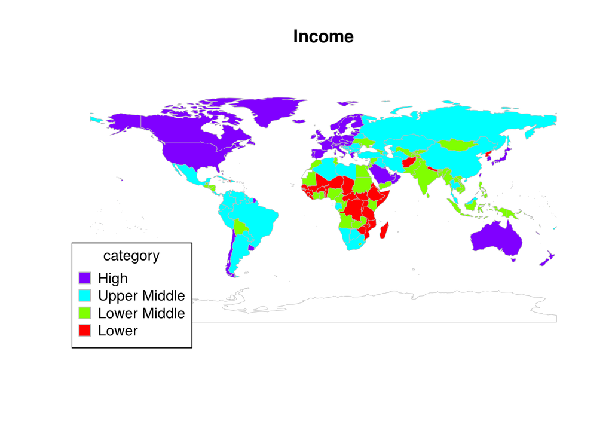

```r
mapCountryData(n,nameColumnToPlot="IncomeValue",colourPalette="rainbow",mapTitle="Income")
```

```
## using catMethod='categorical' for non numeric data in mapCountryData
```

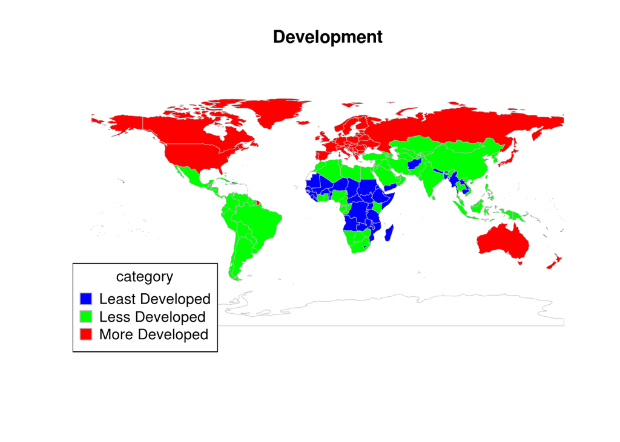

```r
mapCountryData(n,nameColumnToPlot="DevelopmentValue",colourPalette="rainbow",mapTitle="Development")
```

```r
plyr::count(income,c("IncomeValue","DevelopmentValue"))
```

```
##     IncomeValue DevelopmentValue freq
## 1          High   Less Developed   35
## 2          High   More Developed   42
## 3  Upper Middle  Least Developed    1
## 4  Upper Middle   Less Developed   45
## 5  Upper Middle   More Developed   10
## 6  Lower Middle  Least Developed   17
## 7  Lower Middle   Less Developed   33
## 8  Lower Middle   More Developed    2
## 9         Lower  Least Developed   29
## 10        Lower   Less Developed    2
```

The dividing lines here for income are a GNI per capita, or gross national income of ($1025, $4035, $12,467)

Clearly visible on the Income map is the European Union in 2004 and the Gulf Cooperation Council, those Arab Oil Barons. Most in the lower income category are also in the least developed category.

Visible on the development map is the so-called “North-South” divide, between Continental Europe, the Anglosphere, Japan, and the rest of the world.

Also, I included a quick table about the correlation between development and income. It isn’t as clear cut as one may think. Some countries have amazing income but are only moderately developed, like in the Persian Gulf. Ukraine and Moldova are well developed, but have below middling income, because they’re quite rural and suffered a lot from the braindrain and geopolitical shockwaves from the fall of the USSR. Belarus would have suffered as well, but Belarus is the last great dictatorship of Europe.

Now that we have our income regions well defined.

As a test of our data, we’re going to plot the data for the current year for each of these country groupings, in what is referred to as a population pyramid.

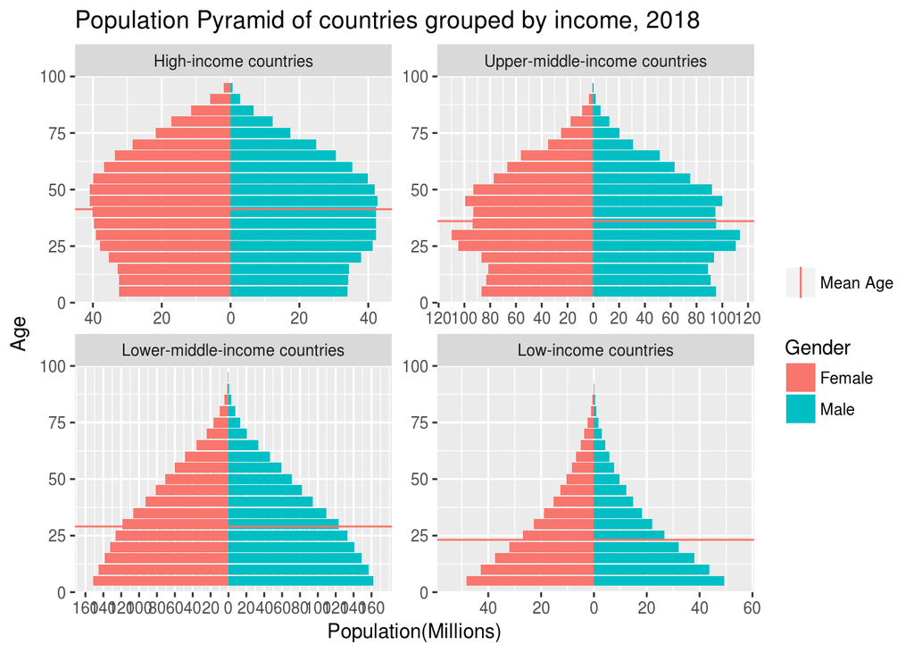

```r
IncomePyramid <- pyramid%>% filter(LocID %in% LocationList$LocID, Time == 2018) %>% mutate(Location = factor(Location,levels=c("High-income countries","Upper-middle-income countries","Lower-middle-income countries","Low-income countries")))

MeanAges <- IncomePyramid%>% group_by(Location) %>% summarize(Mean= dot(AgeGrpStart+2.5,PopCount)/sum(PopCount))

#Can't even begin to tell you how much work it took to put this together
ggplot(IncomePyramid, aes(x=AgeGrpStart,fill=factor(Gender),labels=c("Age")))+geom_bar(data=IncomePyramid%>% filter(str_detect("Male",Gender)),aes(y=PopCount/1000),stat="identity") +geom_bar(data=IncomePyramid%>% filter(str_detect("Female",Gender)),aes(y=-PopCount/1000),stat="identity") +labs(fill="Gender",x="Age",y="Population(Millions)",color="")+coord_flip() + scale_y_continuous(labels=abs,breaks=(-8:8)*20)+ggtitle("Population Pyramid of countries grouped by income, 2018")+geom_vline(data=MeanAges,aes(xintercept=MeanAges$Mean,color="Mean Age"))+scale_x_continuous(limits=c(0,100),expand=c(0,0))+ facet_wrap(~Location,scales="free")
```

Aren’t these pretty graphs? The mean year is based on a rough average assuming each bracket is evenly distributed(It isn’t.)

High income countries are starting to age out, and will experience poulation decline in the upcoming decades. I There’s a visible scar in the upper escelons of the male population in high income countries, partially due to women having better life expectancy regardless of other factors, but also because of the massive casualties of the second world war.

Upper middle countries are starting to have their own thinning out as the result of better access to birth control.

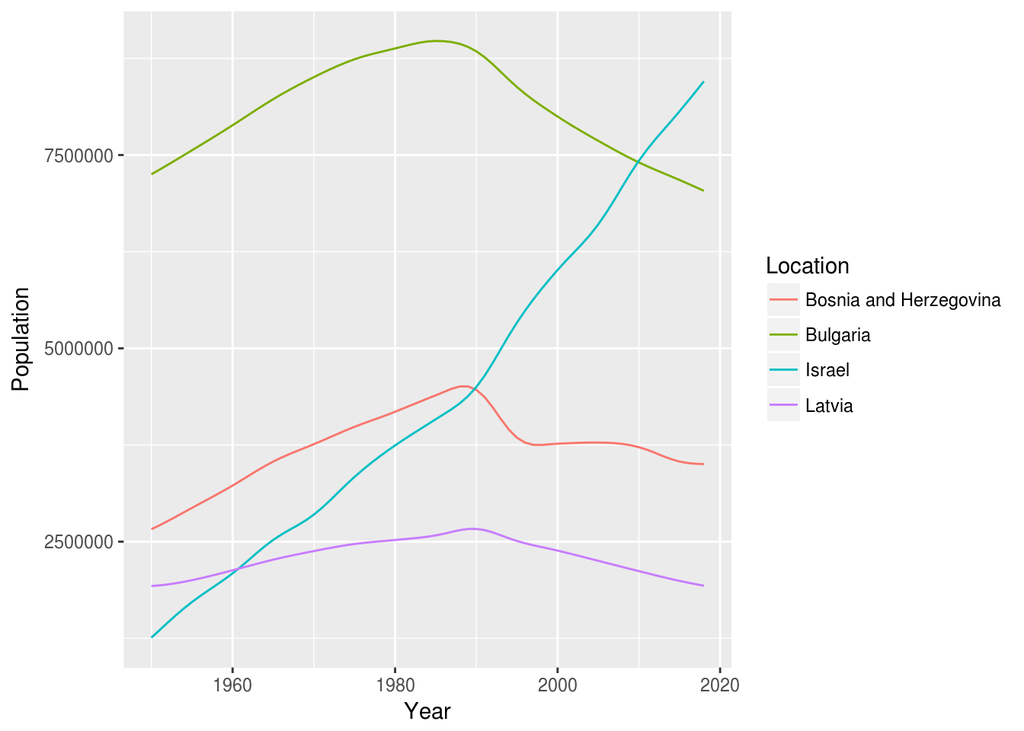

```r
PopData <- pyramid%>%filter(LocID %in%c(376,100,70,428), Gender=="Total" ,Time<=2018)%>% group_by(Time,Location) %>% summarize(YearPop = sum(PopCount))
ggplot(PopData,aes(x=Time,y=YearPop*1000,color=Location))+labs(x="Year",y="Population")+geom_line()
```

Here’s a quick aside about the fall of the iron curtain displayed with **DATA**. I’m not going to go terribly into correlations here, because the effect of the 90s is very apparent on the population of these countries, but I thought this would be a fun one.

We generate this graph by first filtering by location ID, “Total” gender, and year less than the current year(we don’t want their speculative data), then grouping by both time and location.

Bulgaria has been having issues since the collapse of the eastern block keeping its population stable, with more and more young bulgarians going to the nicer pastures of Germany and Western Europe.

Israel as a country is like… 1/3rd immirants, and has the highest birthrate in the developed world, at about 3.1 children per woman. You can see that slight additional uptick in the 1990’s after the fall of the iron curtain and thousands of Russian Jews moving to Israel.

Bosnia’s issue is this little geopolitical struggle known as the Yugoslav wars. Not a fun time.

## Development Set

Now lets do the same pyramid for our Development levels, to do this we’re going to need to merge our population and income data using an inner join.

```r
DevelopmentPyramid <- as.tibble(merge(x=pyramid,y=income,by=c("LocID")))
DevelopmentPyramid
```

```
## # A tibble: 1,761,435 x 11
##    LocID Location     Time AgeGrpStart isFinal Gender PopCount Area
##    <int> <chr>       <int>       <int> <lgl>   <chr>     <dbl> <chr>
##  1     4 Afghanistan  2007          70 FALSE   Male     80.3   Afghanistan
##  2     4 Afghanistan  2090           5 FALSE   Female 1955.    Afghanistan
##  3     4 Afghanistan  1994          20 FALSE   Male    726.    Afghanistan
##  4     4 Afghanistan  2100         100 TRUE    Female    7.13  Afghanistan
##  5     4 Afghanistan  1994          15 FALSE   Male    899.    Afghanistan
##  6     4 Afghanistan  1996          90 FALSE   Male      0.504 Afghanistan
##  7     4 Afghanistan  2062          70 FALSE   Female  849.    Afghanistan
##  8     4 Afghanistan  1994           0 FALSE   Male   1627.    Afghanistan
##  9     4 Afghanistan  2062          80 FALSE   Female  299.    Afghanistan
## 10     4 Afghanistan  2091          95 FALSE   Male      8.98  Afghanistan
## # ... with 1,761,425 more rows, and 3 more variables: Alpha.Code <chr>,
## #   IncomeValue <fct>, DevelopmentValue <fct>
```

We have fewer observations than when we started. This is slightly worrying. Lets take a set difference between the Location IDs of our two sets.

```r
diff <- setdiff(unique(income$LocID),unique(pyramid$LocID))
(income%>% filter(LocID %in% diff))$Area
```

```
##  [1] "Faeroe Islands"            "Isle of Man"
##  [3] "Andorra"                   "Gibraltar"
##  [5] "San Marino"                "Liechtenstein"
##  [7] "Monaco"                    "British Virgin Islands"
##  [9] "Cayman Islands"            "Dominica"
## [11] "Saint Kitts and Nevis"     "Sint Maarten (Dutch part)"
## [13] "Turks and Caicos Islands"  "Bermuda"
## [15] "Greenland"                 "Marshall Islands"
## [17] "Nauru"                     "Northern Mariana Islands"
## [19] "Palau"                     "American Samoa"
## [21] "Tuvalu"
```

What a lovely assortment of microstates and small islands, many of which don’t even have full sovereignty. I’m pretty sure this was the “small” column in our initial location list, a list of countries with a population of less than 90k. I forgot Dominica even existed. These are basically irrelevant to any discussion of population.

[figure not shown]

```r
DevelopmentPyramid <- DevelopmentPyramid %>% select(-c(8,9)) %>% filter(Time==2018)
DevelopmentData <- DevelopmentPyramid %>% group_by(Gender,DevelopmentValue,AgeGrpStart) %>% summarize(TotalPop = sum(PopCount))

MeanAges2 <- DevelopmentData%>% group_by(DevelopmentValue) %>% summarize(Mean= dot(AgeGrpStart+2.5,TotalPop)/sum(TotalPop))

ggplot(DevelopmentData, aes(x=AgeGrpStart,fill=factor(Gender),labels=c("Age")))+geom_bar(data=DevelopmentData%>% filter(str_detect("Male",Gender)),aes(y=TotalPop/1000),stat="identity") +geom_bar(data=DevelopmentData%>% filter(str_detect("Female",Gender)),aes(y=-TotalPop/1000),stat="identity") +labs(fill="Gender",x="Age",y="Population(Millions)",color="")+ coord_flip() + scale_y_continuous(labels=abs,breaks=(-5:5)*40)+ggtitle("Population Pyramid of countries grouped by income, 2018")+geom_vline(data=MeanAges2,aes(xintercept=MeanAges2$Mean,color="Mean Age"))+scale_x_continuous(limits=c(0,100),expand=c(0,0))+ facet_wrap(~DevelopmentValue,scales="free")
```

We remove that sometimes mismatching area column, and do a couple group bys and summaries, and then plug it into the graphing algorithm we made earlier.

I think we’ve had enough fun with Pyramids, now we get to move to a bit of light data analysis, then look at some countries by other metrics.

There’s probably a million different metrics we can correlate to population, such as income, standard of living, but I think the important narrative we can find with regards to population is population growth.

The human population has over tripled over the past 60 years.

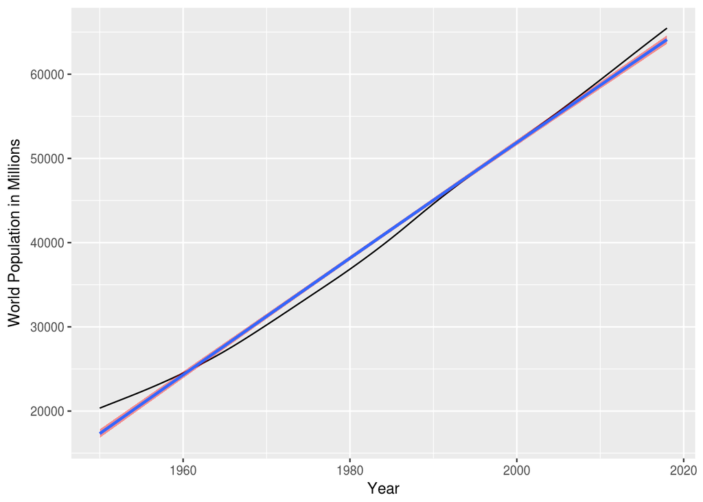

```r
TotalPopData <- pyramid%>%filter(Gender=="Total",Time<=2018)%>% group_by(Time) %>% summarize(YearPop = sum(PopCount))

ggplot(TotalPopData,aes(x=Time,y=YearPop/1000))+labs(x="Year",y="World Population in Millions")+geom_line()+stat_smooth(method = "lm", formula=y~log(x),fill="red")
```

```r
summary(lm(log(Time)~YearPop,data=TotalPopData))
```

```
##
## Call:
## lm(formula = log(Time) ~ YearPop, data = TotalPopData)
##
## Residuals:
##         Min          1Q      Median          3Q         Max
## -0.00230598 -0.00039065  0.00006454  0.00066943  0.00094043
##
## Coefficients:
##                      Estimate        Std. Error t value
## (Intercept) 7.563072396372864 0.000292666524380 25841.9
## YearPop     0.000000000728266 0.000000000006791   107.2
##                        Pr(>|t|)
## (Intercept) <0.0000000000000002 ***
## YearPop     <0.0000000000000002 ***
## ---
## Signif. codes:  0 '***' 0.001 '**' 0.01 '*' 0.05 '.' 0.1 ' ' 1
##
## Residual standard error: 0.0007753 on 67 degrees of freedom
## Multiple R-squared:  0.9942, Adjusted R-squared:  0.9941
## F-statistic: 1.15e+04 on 1 and 67 DF,  p-value: < 0.00000000000000022
```

Electricity has been brought ot some of the most destitute places in the world, even in the past 20 years.

```r
ElectrificationRaw <- read_csv("ElectricityAccess/API_EG.ELC.ACCS.ZS_DS2_en_csv_v2.csv")
```

[figure not shown]

```r
#head(ElectrificationRaw)
Electrification <- ElectrificationRaw %>% select(-c(5:34)) %>% gather("year","ElectricPercent",5:31) %>% select(-c(3:6))
names(Electrification) <- make.names(names(Electrification))
Electrification <- Electrification %>% filter(!is.na(ElectricPercent))

ElectricJoin <- as_tibble(merge(x=Electrification,y=income,by.x = "Country.Code",by.y="Alpha.Code")) %>% select(-c(5)) %>% mutate(year = as.numeric(year))
MeanElectric <- ElectricJoin %>% filter(DevelopmentValue == "Least Developed") %>% group_by(year) %>% summarize(Mean=mean(ElectricPercent))
ElectricJoin %>% filter(DevelopmentValue == "Least Developed") %>% ggplot(aes(x=year,y= ElectricPercent,color = Country.Name)) + geom_line() + geom_smooth(data = MeanElectric, mapping=aes(x=MeanElectric$year,y=MeanElectric$Mean,color="Mean"),size=5, method=lm,formula=y~x) +labs(x="Electrification(percent)",y="Year",color="Country(Least developed)")
```

```r
Electrification %>% filter()
```

```
## # A tibble: 6,958 x 4
##    Country.Name         Country.Code year  ElectricPercent
##    <chr>                <chr>        <chr>           <dbl>
##  1 Aruba                ABW          1990         88.4
##  2 Afghanistan          AFG          1990          0.01000
##  3 Angola               AGO          1990         11.4
##  4 Albania              ALB          1990        100
##  5 Andorra              AND          1990        100
##  6 Arab World           ARB          1990         74.4
##  7 United Arab Emirates ARE          1990        100
##  8 Argentina            ARG          1990         90.6
##  9 Armenia              ARM          1990         97.7
## 10 Antigua and Barbuda  ATG          1990         85.1
## # ... with 6,948 more rows
```

It has brought unprecedented population growth to some of the poorest areas of the earth.

```r
popGrowth <- pyramid%>% filter((Time==1950|Time==2018) &Gender=="Total") %>% group_by(Time,Location,LocID) %>% summarize(sumPop = sum(PopCount)) %>% spread(key = Time,value = sumPop)%>% ungroup()

popGrowth <- popGrowth %>% mutate(PercentGrowth = (`2018`/`1950`)**(1/68)-1)
j<- joinCountryData2Map(popGrowth, joinCode = "UN",nameJoinColumn ='LocID')
```

```
## 194 codes from your data successfully matched countries in the map
## 47 codes from your data failed to match with a country code in the map
## 46 codes from the map weren't represented in your data
```

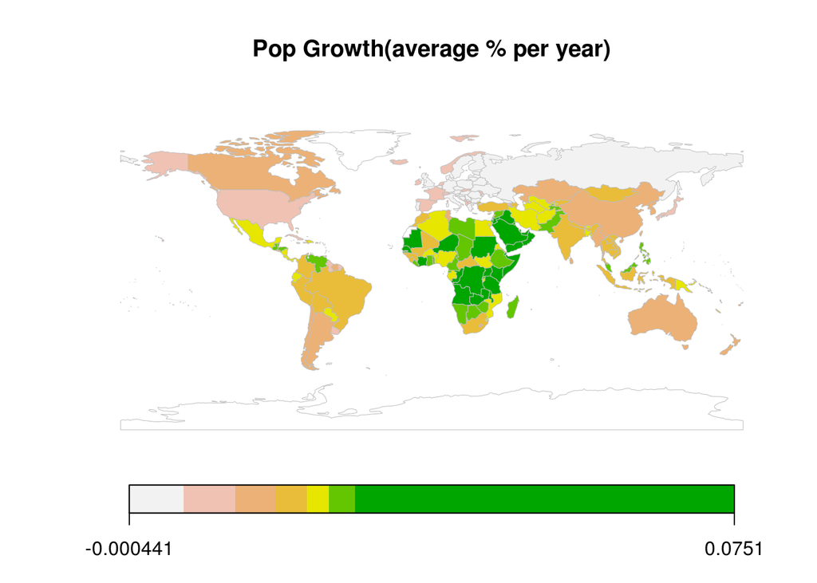

```r
mapCountryData(j,nameColumnToPlot="PercentGrowth",colourPalette='terrain',mapTitle="Pop Growth(average % per year)")
```

```r
popGrowthDevelopment <- as.tibble(merge(x=popGrowth,y=income,by="LocID")) %>% mutate(DevelopmentValue = factor(DevelopmentValue))
summary(lm(PercentGrowth~IncomeValue,data=popGrowthDevelopment))
```

```
##
## Call:
## lm(formula = PercentGrowth ~ IncomeValue, data = popGrowthDevelopment)
##
## Residuals:
##       Min        1Q    Median        3Q       Max
## -0.021072 -0.006659 -0.000631  0.005040  0.060608
##
## Coefficients:
##                         Estimate Std. Error t value             Pr(>|t|)
## (Intercept)             0.014440   0.001331  10.846 < 0.0000000000000002
## IncomeValueUpper Middle 0.002095   0.001973   1.062                 0.29
## IncomeValueLower Middle 0.008139   0.001963   4.147            0.0000507
## IncomeValueLower        0.010147   0.002293   4.424            0.0000162
##
## (Intercept)             ***
## IncomeValueUpper Middle
## IncomeValueLower Middle ***
## IncomeValueLower        ***
## ---
## Signif. codes:  0 '***' 0.001 '**' 0.01 '*' 0.05 '.' 0.1 ' ' 1
##
## Residual standard error: 0.0104 on 191 degrees of freedom
## Multiple R-squared:  0.1342, Adjusted R-squared:  0.1206
## F-statistic: 9.872 on 3 and 191 DF,  p-value: 0.000004401
```

```r
summary(lm(PercentGrowth~DevelopmentValue,data=popGrowthDevelopment))
```

```
##
## Call:
## lm(formula = PercentGrowth ~ DevelopmentValue, data = popGrowthDevelopment)
##
## Residuals:
##       Min        1Q    Median        3Q       Max
## -0.020215 -0.004347 -0.000372  0.003294  0.053326
##
## Coefficients:
##                                 Estimate Std. Error t value
## (Intercept)                     0.024710   0.001252  19.734
## DevelopmentValueLess Developed -0.002989   0.001504  -1.988
## DevelopmentValueMore Developed -0.018829   0.001781 -10.574
##                                           Pr(>|t|)
## (Intercept)                    <0.0000000000000002 ***
## DevelopmentValueLess Developed              0.0483 *
## DevelopmentValueMore Developed <0.0000000000000002 ***
## ---
## Signif. codes:  0 '***' 0.001 '**' 0.01 '*' 0.05 '.' 0.1 ' ' 1
##
## Residual standard error: 0.008493 on 192 degrees of freedom
## Multiple R-squared:  0.4194, Adjusted R-squared:  0.4134
## F-statistic: 69.36 on 2 and 192 DF,  p-value: < 0.00000000000000022
```

Here, I take our old population pyramid, compare the 2018 population to the 1950 population using an an average exponential growth formula. Then we perform a linear regression to see if Percent growth is correlated with income value or development value.

But I think the beauty of this map is that I didn’t even really need to do regression testing. We know which areas of the map are developed and undeveloped already, and the map just tells us what we want to know.

We’ve also increased the bounty of the earth. I’m using cereal statistic here.

```r
CerealRaw <- read_csv("AgriculturalProductivity/API_1_DS2_en_csv_v2_9911808.csv")
names(CerealRaw)
```

```
##  [1] "Country Name"   "Country Code"   "Indicator Name" "Indicator Code"
##  [5] "1960"           "1961"           "1962"           "1963"
##  [9] "1964"           "1965"           "1966"           "1967"
## [13] "1968"           "1969"           "1970"           "1971"
## [17] "1972"           "1973"           "1974"           "1975"
## [21] "1976"           "1977"           "1978"           "1979"
## [25] "1980"           "1981"           "1982"           "1983"
## [29] "1984"           "1985"           "1986"           "1987"
## [33] "1988"           "1989"           "1990"           "1991"
## [37] "1992"           "1993"           "1994"           "1995"
## [41] "1996"           "1997"           "1998"           "1999"
## [45] "2000"           "2001"           "2002"           "2003"
## [49] "2004"           "2005"           "2006"           "2007"
## [53] "2008"           "2009"           "2010"           "2011"
## [57] "2012"           "2013"           "2014"           "2015"
## [61] "2016"           "2017"           "X63"
```

```r
head(CerealRaw)
```

```
## # A tibble: 6 x 63
##   `Country Name` `Country Code` `Indicator Name`  `Indicator Code`  `1960`
##   <chr>          <chr>          <chr>             <chr>              <dbl>
## 1 Aruba          ABW            Agricultural raw… TX.VAL.AGRI.ZS.… NA
## 2 Aruba          ABW            Agricultural raw… TM.VAL.AGRI.ZS.… NA
## 3 Aruba          ABW            Rural population… SP.RUR.TOTL.ZS    4.92e1
## 4 Aruba          ABW            Rural population… SP.RUR.TOTL.ZG    3.18e0
## 5 Aruba          ABW            Rural population  SP.RUR.TOTL       2.67e4
## 6 Aruba          ABW            Employment in ag… SL.AGR.EMPL.ZS   NA
## # ... with 58 more variables: `1961` <dbl>, `1962` <dbl>, `1963` <dbl>,
## #   `1964` <dbl>, `1965` <dbl>, `1966` <dbl>, `1967` <dbl>, `1968` <dbl>,
## #   `1969` <dbl>, `1970` <dbl>, `1971` <dbl>, `1972` <dbl>, `1973` <dbl>,
## #   `1974` <dbl>, `1975` <dbl>, `1976` <dbl>, `1977` <dbl>, `1978` <dbl>,
## #   `1979` <dbl>, `1980` <dbl>, `1981` <dbl>, `1982` <dbl>, `1983` <dbl>,
## #   `1984` <dbl>, `1985` <dbl>, `1986` <dbl>, `1987` <dbl>, `1988` <dbl>,
## #   `1989` <dbl>, `1990` <dbl>, `1991` <dbl>, `1992` <dbl>, `1993` <dbl>,
## #   `1994` <dbl>, `1995` <dbl>, `1996` <dbl>, `1997` <dbl>, `1998` <dbl>,
## #   `1999` <dbl>, `2000` <dbl>, `2001` <dbl>, `2002` <dbl>, `2003` <dbl>,
## #   `2004` <dbl>, `2005` <dbl>, `2006` <dbl>, `2007` <dbl>, `2008` <dbl>,
## #   `2009` <dbl>, `2010` <dbl>, `2011` <dbl>, `2012` <dbl>, `2013` <dbl>,
## #   `2014` <dbl>, `2015` <dbl>, `2016` <dbl>, `2017` <dbl>, X63 <chr>
```

Ooooh. This is a particularly ugly dataset. It has multiple indicators in the same data.

```r
levels(factor(CerealRaw$'Indicator Name'))
```

```
##  [1] "Access to electricity, rural (% of rural population)"
##  [2] "Agricultural irrigated land (% of total agricultural land)"
##  [3] "Agricultural land (% of land area)"
##  [4] "Agricultural land (sq. km)"
##  [5] "Agricultural machinery, tractors"
##  [6] "Agricultural machinery, tractors per 100 sq. km of arable land"
##  [7] "Agricultural methane emissions (% of total)"
##  [8] "Agricultural methane emissions (thousand metric tons of CO2 equivalent)"
##  [9] "Agricultural nitrous oxide emissions (% of total)"
## [10] "Agricultural nitrous oxide emissions (thousand metric tons of CO2 equivalent)"
## [11] "Agricultural raw materials exports (% of merchandise exports)"
## [12] "Agricultural raw materials imports (% of merchandise imports)"
## [13] "Agriculture, value added (current US$)"
## [14] "Agriculture, value added (% of GDP)"
## [15] "Annual freshwater withdrawals, agriculture (% of total freshwater withdrawal)"
```

[output cut: 29 more lines]

And like 44 different data sets. Ok, first we need to do basically what we did to electrification.

```r
Cereal <-CerealRaw %>% select(-c(5:34)) %>% gather("year","Num Element",5:31) %>% select(-c(5:6))
head(Cereal)
```

```
## # A tibble: 6 x 6
##   `Country Name` `Country Code` `Indicator Name`    `Indicator Code` year
##   <chr>          <chr>          <chr>               <chr>            <chr>
## 1 Aruba          ABW            Agricultural raw m… TX.VAL.AGRI.ZS.… 1990
## 2 Aruba          ABW            Agricultural raw m… TM.VAL.AGRI.ZS.… 1990
## 3 Aruba          ABW            Rural population (… SP.RUR.TOTL.ZS   1990
## 4 Aruba          ABW            Rural population g… SP.RUR.TOTL.ZG   1990
## 5 Aruba          ABW            Rural population    SP.RUR.TOTL      1990
## 6 Aruba          ABW            Employment in agri… SL.AGR.EMPL.ZS   1990
## # ... with 1 more variable: `Num Element` <dbl>
```

Now we split this data up again, then we can make it into its own tables.

```r
CerealSpread<-Cereal %>%select(-c(3)) %>% spread('Indicator Code','Num Element') %>% mutate(year=as.numeric(year))
CerealIndicatorNames <- Cereal %>% select(c(3,4)) %>% unique()
head(CerealIndicatorNames)#This gives us names for our collumns, and by referencing this one....
```

```
## # A tibble: 6 x 2
##   `Indicator Name`                                        `Indicator Code`
##   <chr>                                                   <chr>
## 1 Agricultural raw materials exports (% of merchandise e… TX.VAL.AGRI.ZS.…
## 2 Agricultural raw materials imports (% of merchandise i… TM.VAL.AGRI.ZS.…
## 3 Rural population (% of total population)                SP.RUR.TOTL.ZS
## 4 Rural population growth (annual %)                      SP.RUR.TOTL.ZG
## 5 Rural population                                        SP.RUR.TOTL
## 6 Employment in agriculture (% of total employment) (mod… SL.AGR.EMPL.ZS
```

```r
head(CerealSpread)
```

```
## # A tibble: 6 x 47
##   `Country Name` `Country Code`  year AG.AGR.TRAC.NO AG.CON.FERT.PT.ZS
##   <chr>          <chr>          <dbl>          <dbl>             <dbl>
## 1 Afghanistan    AFG             1990            120                NA
## 2 Afghanistan    AFG             1991            120                NA
## 3 Afghanistan    AFG             1992            110                NA
## 4 Afghanistan    AFG             1993            110                NA
## 5 Afghanistan    AFG             1994            110                NA
## 6 Afghanistan    AFG             1995            110                NA
## # ... with 42 more variables: AG.CON.FERT.ZS <dbl>, AG.LND.AGRI.K2 <dbl>,
## #   AG.LND.AGRI.ZS <dbl>, AG.LND.ARBL.HA <dbl>, AG.LND.ARBL.HA.PC <dbl>,
## #   AG.LND.ARBL.ZS <dbl>, AG.LND.CREL.HA <dbl>, AG.LND.CROP.ZS <dbl>,
## #   AG.LND.EL5M.RU.K2 <dbl>, AG.LND.EL5M.RU.ZS <dbl>,
## #   AG.LND.FRST.K2 <dbl>, AG.LND.FRST.ZS <dbl>, AG.LND.IRIG.AG.ZS <dbl>,
## #   AG.LND.PRCP.MM <dbl>, AG.LND.TOTL.K2 <dbl>, AG.LND.TOTL.RU.K2 <dbl>,
## #   AG.LND.TRAC.ZS <dbl>, AG.PRD.CREL.MT <dbl>, AG.PRD.CROP.XD <dbl>,
## #   AG.PRD.FOOD.XD <dbl>, AG.PRD.LVSK.XD <dbl>, AG.SRF.TOTL.K2 <dbl>,
## #   AG.YLD.CREL.KG <dbl>, EG.ELC.ACCS.RU.ZS <dbl>,
## #   EN.ATM.METH.AG.KT.CE <dbl>, EN.ATM.METH.AG.ZS <dbl>,
## #   EN.ATM.NOXE.AG.KT.CE <dbl>, EN.ATM.NOXE.AG.ZS <dbl>,
## #   EN.POP.EL5M.RU.ZS <dbl>, ER.H2O.FWAG.ZS <dbl>, NV.AGR.TOTL.CD <dbl>,
## #   NV.AGR.TOTL.ZS <dbl>, SI.POV.RUGP <dbl>, SI.POV.RUHC <dbl>,
## #   SL.AGR.EMPL.FE.ZS <dbl>, SL.AGR.EMPL.MA.ZS <dbl>,
## #   SL.AGR.EMPL.ZS <dbl>, SP.RUR.TOTL <dbl>, SP.RUR.TOTL.ZG <dbl>,
## #   SP.RUR.TOTL.ZS <dbl>, TM.VAL.AGRI.ZS.UN <dbl>, TX.VAL.AGRI.ZS.UN <dbl>
```

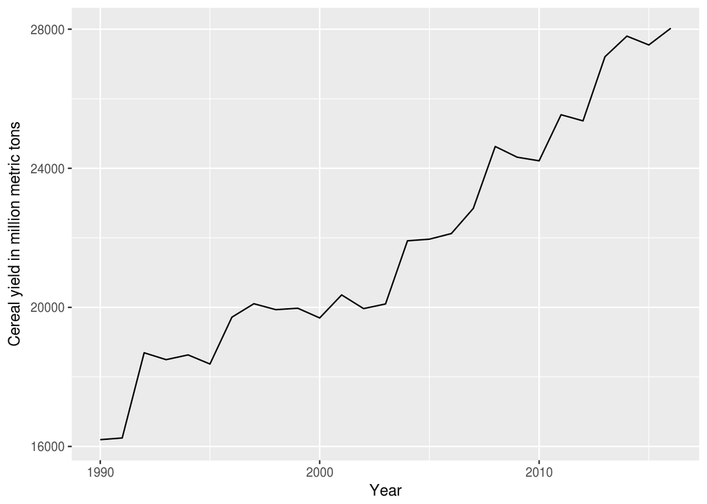

```r
CerealTotalYield <- CerealSpread %>% select(c("Country Name","Country Code","year","AG.PRD.CREL.MT")) %>% mutate(AG.PRD.CREL.MT=as.numeric(AG.PRD.CREL.MT)) %>% mutate(year=as.numeric(year))
aggregate(AG.PRD.CREL.MT~year,CerealTotalYield,sum) %>% ggplot(aes(x=year,y=AG.PRD.CREL.MT/1000000))+geom_line()+labs(y="Cereal yield in million metric tons",x="Year")
```

So apparently we’ve almost doubled our cereal yields in the past 30 years.

So we’ve made this nice graph to more or less prove our original point, that the data shows that crop yields have almost doubled over the past 30 years, now lets look at individual countries and how they’ve increased their yield per hectacre.

```r
CerealYield <- CerealSpread %>% select(c("Country Name","Country Code","year","AG.YLD.CREL.KG"))
names(CerealYield)<- make.names(names(CerealYield))
names(CerealYield)[2]<- "Alpha.Code"

CerealYieldMerge <-as.tibble(merge(x=CerealYield,y=income,by="Alpha.Code"))
```

Now that we’ve made our merge table, we can visualize the yield.

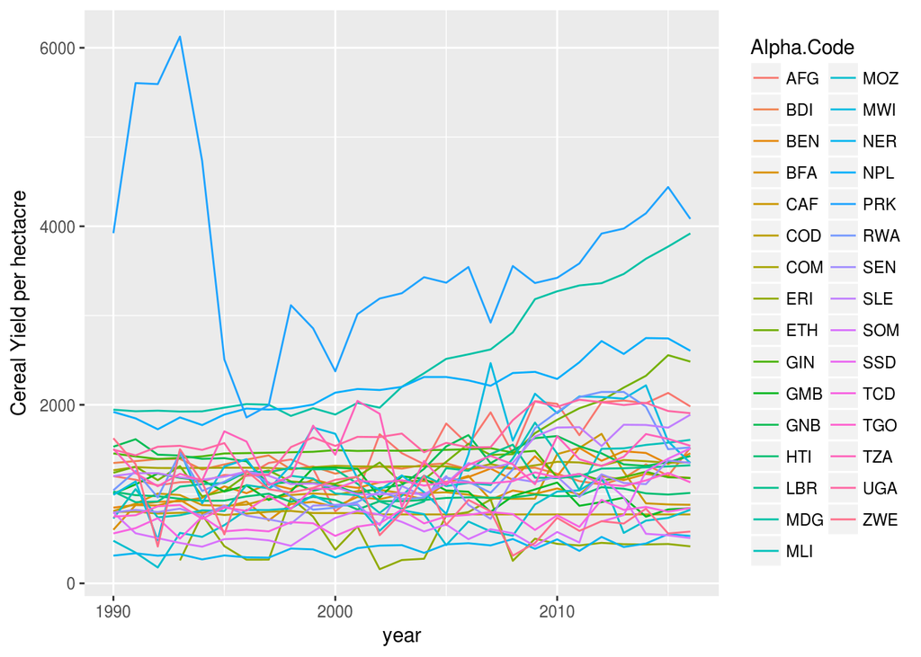

```r
CerealYieldMerge %>% filter(IncomeValue == "Lower" &!is.na(AG.YLD.CREL.KG)) %>% ggplot(aes(x=year,y=AG.YLD.CREL.KG,color=Alpha.Code))+geom_line() + labs(y="Cereal Yield per hectacre")
```

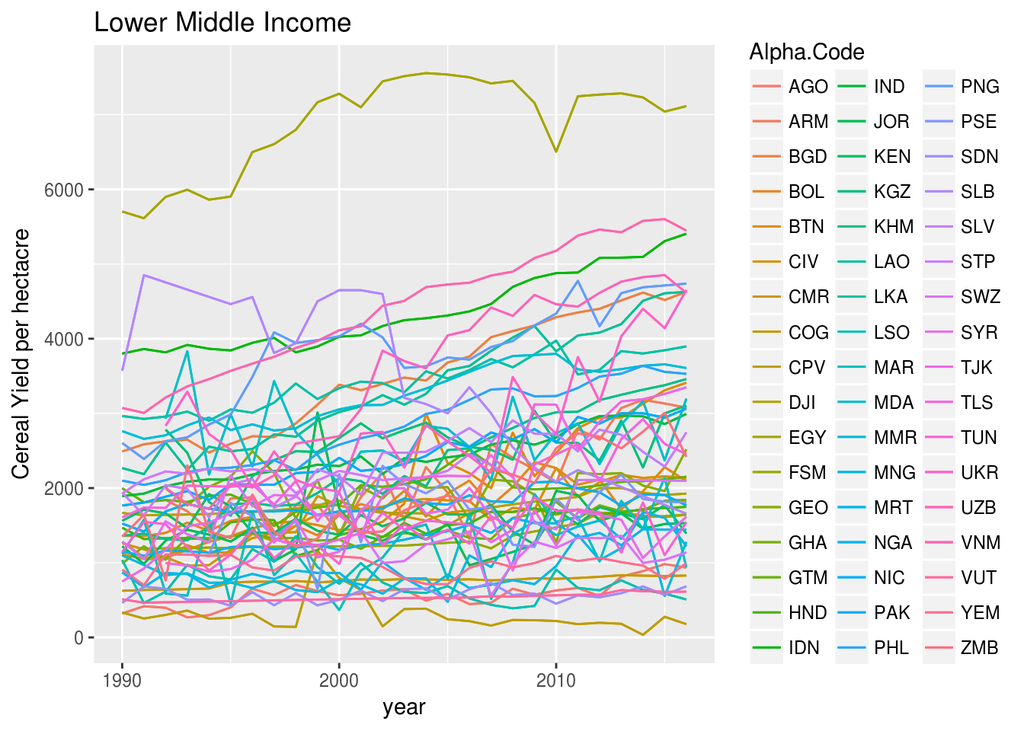

```r
CerealYieldMerge %>% filter(IncomeValue =="Lower Middle"&Alpha.Code!="PRK" &!is.na(AG.YLD.CREL.KG)) %>% ggplot(aes(x=year,y=AG.YLD.CREL.KG,color=Alpha.Code))+geom_line() + labs(y="Cereal Yield per hectacre")+geom_line()+ggtitle("Lower Middle Income")
```

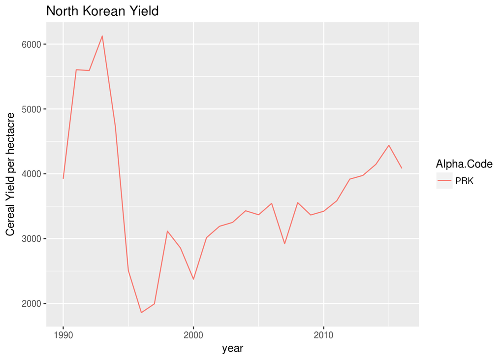

```r
CerealYieldMerge %>% filter(Alpha.Code=="PRK" &!is.na(AG.YLD.CREL.KG)) %>% ggplot(aes(x=year,y=AG.YLD.CREL.KG,color=Alpha.Code))+geom_line() + labs(y="Cereal Yield per hectacre")+ggtitle("North Korean Yield")
```

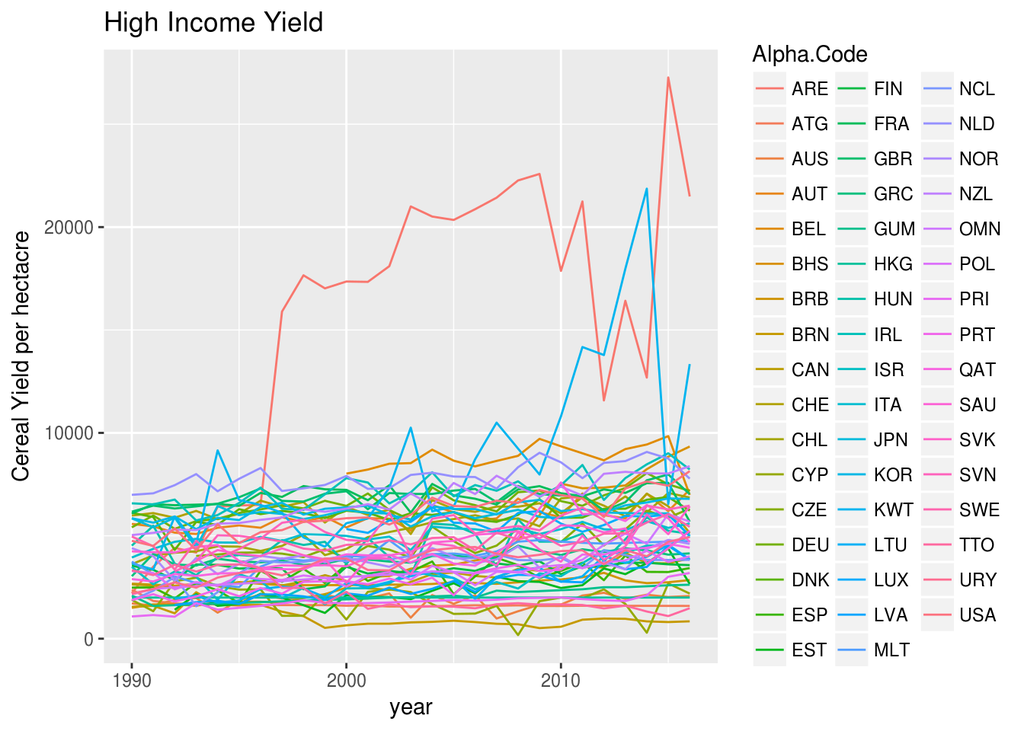

```r
CerealYieldMerge %>% filter(IncomeValue =="High"  &!is.na(AG.YLD.CREL.KG)) %>% ggplot(aes(x=year,y=AG.YLD.CREL.KG,color=Alpha.Code))+geom_line() + labs(y="Cereal Yield per hectacre")+ggtitle("High Income Yield")
```

All in all the primary thing that I got out of all of this realtively noisy data, is that I could see the famine in North Korea simply from its crop yields. While the most agriculturally developed in the poorest section of the world, North Korea basically suffered agricultural collapse in the mid 90’s due to devestating floods that ruined North Korean electircal and agricultura infrastructure. They had to beg the international community for support at a great cost to their ideology of self-reliance.

The past 50 years has also caused the greatest migration in human history from poor regions to rich ones.

```r
MigrationRaw <- read_csv("Migration/API_SM.POP.NETM_DS2_en_csv_v2.csv")
head(MigrationRaw)
```

```
## # A tibble: 6 x 63
##   `Country Name` `Country Code` `Indicator Name` `Indicator Code` `1960`
##   <chr>          <chr>          <chr>            <chr>            <chr>
## 1 Aruba          ABW            Net migration    SM.POP.NETM      <NA>
## 2 Afghanistan    AFG            Net migration    SM.POP.NETM      <NA>
## 3 Angola         AGO            Net migration    SM.POP.NETM      <NA>
## 4 Albania        ALB            Net migration    SM.POP.NETM      <NA>
## 5 Andorra        AND            Net migration    SM.POP.NETM      <NA>
## 6 Arab World     ARB            Net migration    SM.POP.NETM      <NA>
## # ... with 58 more variables: `1961` <chr>, `1962` <int>, `1963` <chr>,
## #   `1964` <chr>, `1965` <chr>, `1966` <chr>, `1967` <int>, `1968` <chr>,
## #   `1969` <chr>, `1970` <chr>, `1971` <chr>, `1972` <int>, `1973` <chr>,
## #   `1974` <chr>, `1975` <chr>, `1976` <chr>, `1977` <int>, `1978` <chr>,
## #   `1979` <chr>, `1980` <chr>, `1981` <chr>, `1982` <int>, `1983` <chr>,
## #   `1984` <chr>, `1985` <chr>, `1986` <chr>, `1987` <int>, `1988` <chr>,
## #   `1989` <chr>, `1990` <chr>, `1991` <chr>, `1992` <int>, `1993` <chr>,
## #   `1994` <chr>, `1995` <chr>, `1996` <chr>, `1997` <int>, `1998` <chr>,
## #   `1999` <chr>, `2000` <chr>, `2001` <chr>, `2002` <int>, `2003` <chr>,
## #   `2004` <chr>, `2005` <chr>, `2006` <chr>, `2007` <int>, `2008` <chr>,
## #   `2009` <chr>, `2010` <chr>, `2011` <chr>, `2012` <int>, `2013` <chr>,
## #   `2014` <chr>, `2015` <chr>, `2016` <chr>, `2017` <chr>, X63 <chr>
```

Migration, simliar to electrification and Cereal, is a pretty ugly data set, because on CSVs its easier to list things by countries vs years, wheras for data analytics its easier to regularize the data, turning the year into another aspect of our primary key.

```r
Migration <- MigrationRaw %>% gather("year","PopMigration",5:61) %>% filter(!is.na(PopMigration)) %>% select(-c(3:6)) %>% mutate(PopMigration = as.numeric(PopMigration))
names(Migration) <- make.names(names(Migration))
head(Migration)
```

```
## # A tibble: 6 x 4
##   Country.Name         Country.Code year  PopMigration
##   <chr>                <chr>        <chr>        <dbl>
## 1 Aruba                ABW          1962         -4323
## 2 Afghanistan          AFG          1962        -20000
## 3 Angola               AGO          1962       -135000
## 4 Albania              ALB          1962           -99
## 5 Arab World           ARB          1962       -502251
## 6 United Arab Emirates ARE          1962         37882
```

```r
MigrationJoin <- as.tibble(merge(x=Migration,y=countryCodes,by.x="Country.Code",by.y="Alpha.Code")) %>% filter(year=="2012")
MigrationPos <- MigrationJoin %>% filter(PopMigration>=0)

MigrationNeg <- MigrationJoin %>% filter(PopMigration<0) %>% mutate(PopMigration = -PopMigration)
j<- joinCountryData2Map(MigrationPos, joinCode = "UN",nameJoinColumn ='LocID')
```

```
## 73 codes from your data successfully matched countries in the map
## 1 codes from your data failed to match with a country code in the map
## 168 codes from the map weren't represented in your data
```

```r
k<- joinCountryData2Map(MigrationNeg, joinCode = "UN",nameJoinColumn ='LocID')
```

```
## 120 codes from your data successfully matched countries in the map
## 0 codes from your data failed to match with a country code in the map
## 122 codes from the map weren't represented in your data
```

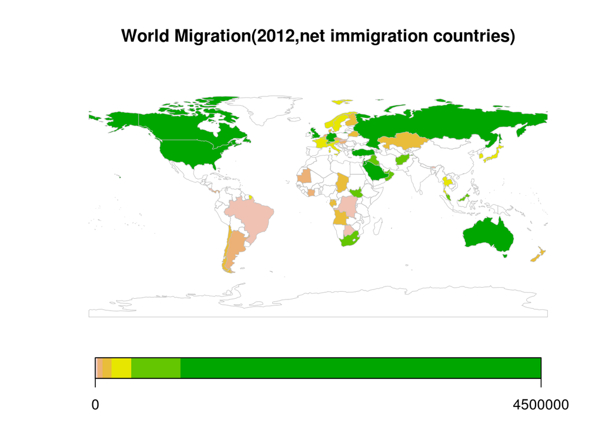

```r
mapCountryData(j,nameColumnToPlot="PopMigration",colourPalette='terrain',mapTitle="World Migration(2012,net immigration countries)")
```

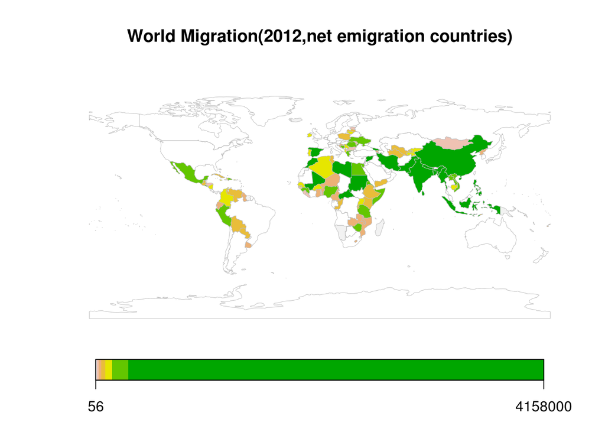

```r
mapCountryData(k,nameColumnToPlot="PopMigration",colourPalette='terrain',mapTitle="World Migration(2012,net emigration countries)")
```

Unfortunately, we don’t have good ways of showing the full extent of country data with this function, but we can get a general feel for which countries are the biggest net migrants by taking the maxs in each data set. Sometimes our tools are bad, and we should find better ones.

```r
MigrationPos %>% arrange(desc(PopMigration)) %>% head(10)
```

```
## # A tibble: 10 x 6
##    Country.Code Country.Name       year  PopMigration Area           LocID
##    <chr>        <chr>              <chr>        <dbl> <chr>          <int>
##  1 USA          United States      2012       4500000 United States…   840
##  2 DEU          Germany            2012       1777126 Germany          276
##  3 TUR          Turkey             2012       1627172 Turkey           792
##  4 SAU          Saudi Arabia       2012       1590000 Saudi Arabia     682
##  5 LBN          Lebanon            2012       1250000 Lebanon          422
##  6 CAN          Canada             2012       1145721 Canada           124
##  7 RUS          Russian Federation 2012       1017884 Russian Feder…   643
##  8 GBR          United Kingdom     2012        990000 United Kingdom   826
##  9 JOR          Jordan             2012        975285 Jordan           400
## 10 AUS          Australia          2012        913107 Australia         36
```

```r
MigrationNeg %>% arrange(desc(PopMigration)) %>% head(10)
```

```
## # A tibble: 10 x 6
##    Country.Code Country.Name         year  PopMigration Area         LocID
##    <chr>        <chr>                <chr>        <dbl> <chr>        <int>
##  1 SYR          Syrian Arab Republic 2012       4157896 Syrian Arab…   760
##  2 IND          India                2012       2578213 India          356
##  3 BGD          Bangladesh           2012       2526483 Bangladesh      50
##  4 CHN          China                2012       1698448 China          156
##  5 PAK          Pakistan             2012       1181920 Pakistan       586
##  6 IDN          Indonesia            2012        835000 Indonesia      360
##  7 PHL          Philippines          2012        650000 Philippines    608
##  8 SDN          Sudan                2012        589384 Sudan          729
##  9 ESP          Spain                2012        570000 Spain          724
## 10 LKA          Sri Lanka            2012        484772 Sri Lanka      144
```

The other top emmigrating countries tend to be some of the most populated ones on the planet, and the ones with the greatest population density in inhabited regions.

I guess what I’m trying to present as a message that we’re living in the most complicated time in human history, but we also collect enough data that we can get a good grasp on exactly how complicated it is, and maybe with enough eyes on the data we can pick out some patterns.